# Lab 4: Connecting Hypothesis Testing and Confidence Intervals

### 2) Gender Under High Stress

Does this sample provide evidence of a significant difference between the proportions of male and female students who are under high stress?

```r
females.stress <- subset (Stress, Gender == "Female")
View(females.stress)
summary(females.stress)
```

```
##   high normal
##     38    113
```

The data above compares the proportion of females that recorded high and normal stress levels. 38/151 (or 25% of the female population) report high stress.

```r
males.stress <- subset (Stress, Gender == "Male")

View(males.stress)
summary(males.stress)
```

```
##   high normal
##     18     84
```

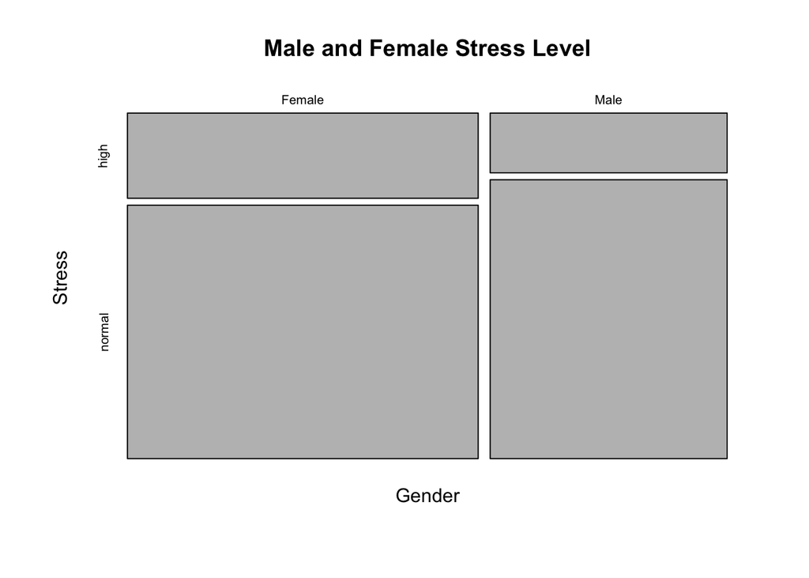

```r
plot(table(Gender,Stress), main = "Male and Female Stress Level")
```

The graph above shows a visual difference between the two proportions. To test both these hypotheses, we will run a two proportion test to measure if there is a difference in stress scores between the two genders.

The null hypothesis is that there is no difference in the stress score between male and female students, where H_O: p_F = p_M. The alternative hypothesis is that there is a difference in the stress score of male and female students, where H_A: p_F ≠ p_M.

```r
prop.test(table(Stress,Gender))
```

```
##
##  2-sample test for equality of proportions with continuity correction
##
## data:  table(Stress, Gender)
## X-squared = 1.5843, df = 1, p-value = 0.2081
## alternative hypothesis: two.sided
## 95 percent confidence interval:
##  -0.04696727  0.25690200
## sample estimates:
##    prop 1    prop 2
## 0.6785714 0.5736041
```

### 3) GPA and Stress

Does this sample provide evidence of a significant difference between the average GPA of “normal stress” students and the average GPA of “high stress” students at this college?

```r
normal.gpa <- subset (GPA, Stress == "normal")
View(normal.gpa)
summary(normal.gpa)
```

```
##    Min. 1st Qu.  Median    Mean 3rd Qu.    Max.
##   2.000   3.000   3.250   3.209   3.500   4.000
```

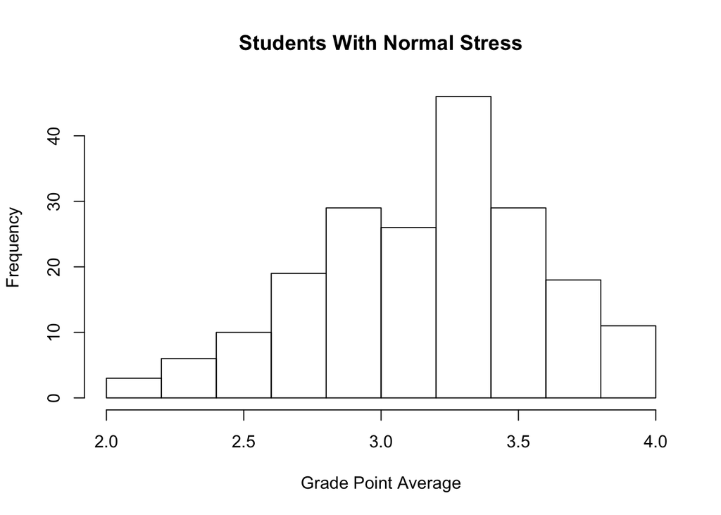

```r
hist(normal.gpa, main ="Students With Normal Stress", xlab = "Grade Point Average")
```

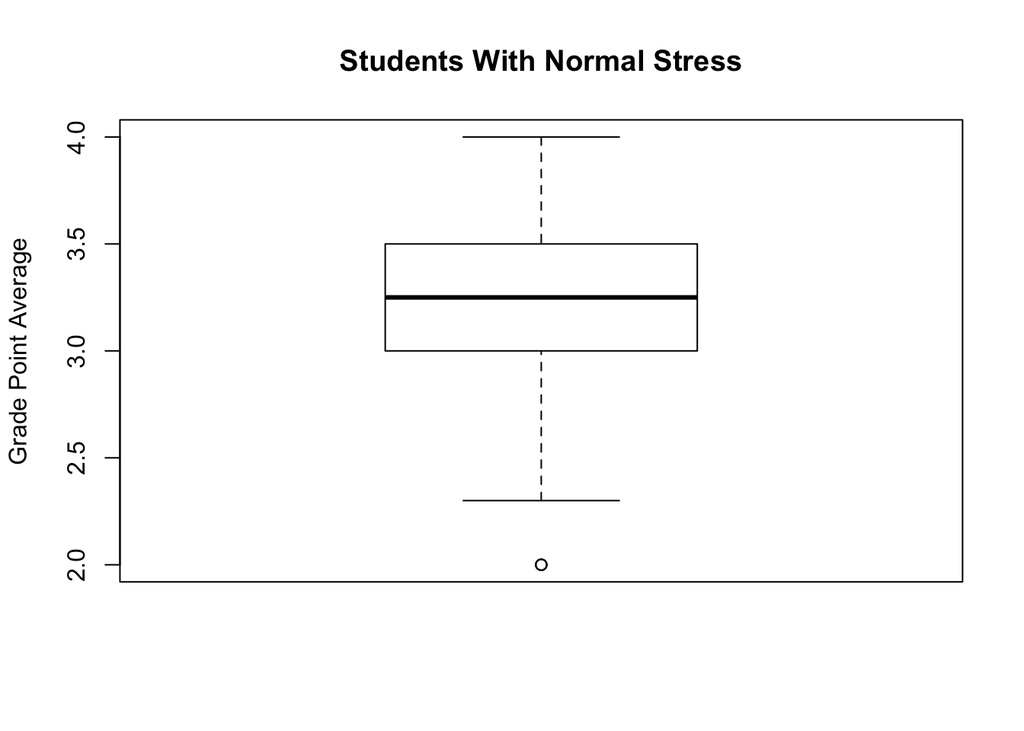

```r
boxplot(normal.gpa, main ="Students With Normal Stress", ylab = "Grade Point Average")
```

Students at College X reporting normal stress level averages a GPA of 3.21. The median is slightly greater than the mean, and the histogram displays a left-skewed unimodal distribution.

```r
high.gpa <- subset (GPA, Stress == "high")
View(high.gpa)
summary(high.gpa)
```

```
##    Min. 1st Qu.  Median    Mean 3rd Qu.    Max.
##   2.500   3.065   3.350   3.366   3.603   4.000
```

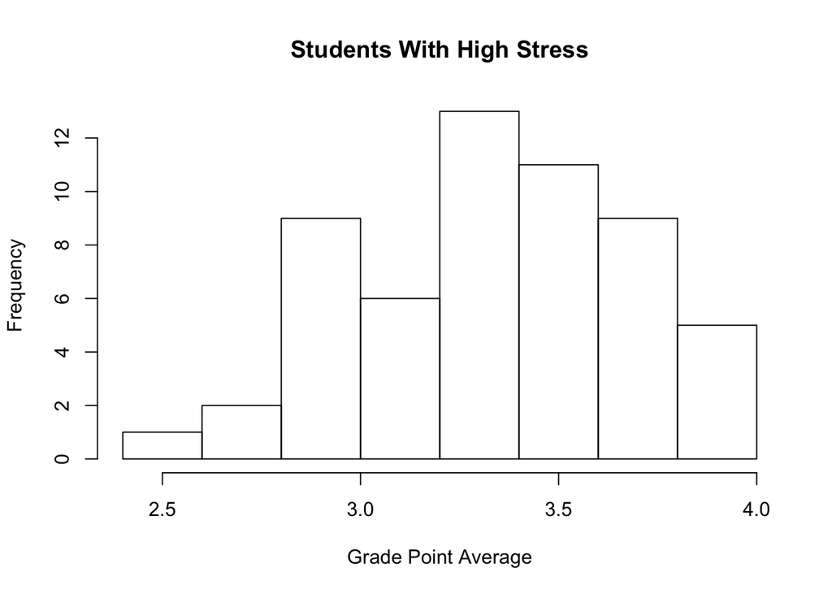

```r
hist(high.gpa, main ="Students With High Stress", xlab = "Grade Point Average")
```

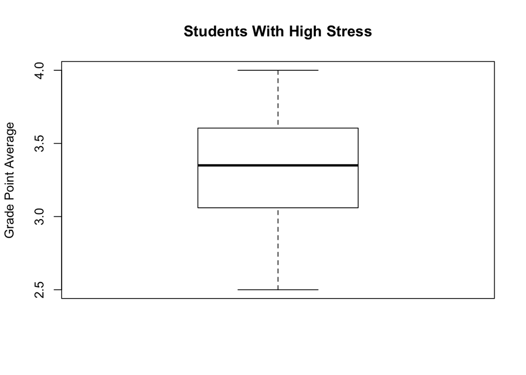

```r
boxplot(high.gpa, main ="Students With High Stress", ylab = "Grade Point Average")
```

To test if there is a significant difference between the average GPA of “normal stress” students and the average GPA of “high stress” students at College X, we will run a two mean test.

The null hypothesis is that there is no difference in the average GPA of high stress and normal stress students, where H_O: μ_F = μ_M. The alternative hypothesis is that there is a difference in the GPA of high stress and normal stress students, where H_A: μ_F ≠ μ_M.

```r
t.test(GPA~Stress, mu=0)
```

```
##
##  Welch Two Sample t-test
##
## data:  GPA by Stress
## t = 2.8397, df = 102.11, p-value = 0.005451
## alternative hypothesis: true difference in means is not equal to 0
## 95 percent confidence interval:
##  0.04741781 0.26711265
## sample estimates:
##   mean in group high mean in group normal
##             3.366250             3.208985
```

The p-value of 0.0055 is significantly less than 0.05, which is enough to reject the null hypothesis. We can conclude that there is a difference between the GPA of students with high stress and normal stress.

We are 95% confident that the difference between the average GPA of normal stress students and the average GPA of high-stress students at College X is between 0.047 and 0.27. There is a 0.047 and 0.27 difference in GPA between high stress and low-stress students.